# R packages for using Stan

Greg Snow

September 22, 2021

# R packages for working with Stan

## Stan

- R recognizes that it may not be the best tool for every job.
- R packages for interfacing with other tools are common because of this.
- Stan (https://mc-stan.org/) is a powerful tool/language for doing Bayesian model fitting.

## A simple Stan model for comparing 2 means

I have the following saved in a file “two_sample.stan”

```
data {
 int<lower=1> N;
 real y[N];
 int<lower=1, upper=2> g[N];
}

parameters {
  real mu[2];
  real<lower=0> sigma[2];
}

model {
  for(i in 1:N) {
    y[i] ~ normal(mu[g[i]], sigma[g[i]]);
  }
}

generated quantities {
  real mu_diff;
  real sigma_ratio;

  mu_diff = mu[1] - mu[2];
  sigma_ratio = sigma[1]/sigma[2];
}
```

# The rstan package

## Compiling the Stan model

```r
# load the package
library(rstan)

# run on multiple cores
options(mc.cores = parallel::detectCores())

# save compiled models so we don't need to recompile
rstan_options(auto_write = TRUE)

# compile the model
twosamp.stan <- stan_model(file='two_sample.stan'); beepr::beep()
```

## Prepare data

Is there a difference in weight between Female, Adelie penguins on Biscoe vs. Dream islands?

```r
library(palmerpenguins)
w <- penguins$species=='Adelie' &
      penguins$sex=='female' &
      penguins$island %in% c("Biscoe", "Dream") &
      !is.na(penguins$body_mass_g) &
      !is.na(penguins$sex)

BvD.standat <- list(
  N=sum(w),
  y=penguins$body_mass_g[w],
  g=as.integer(penguins$island[w])
)

str(BvD.standat)
```

```
## List of 3
##  $ N: int 49
##  $ y: int [1:49] 3400 3800 3800 3200 3150 3250 3300 3325 3550 3300 ...
##  $ g: int [1:49] 1 1 1 1 1 2 2 2 2 2 ...
```

## Finding the mode

The `optimizing` function will find the mode (maximum point) of the posterior:

```r
optimizing(twosamp.stan, BvD.standat)
```

```
$par
      mu[1]       mu[2]    sigma[1]
3369.318261 3344.505880  335.574488
   sigma[2]     mu_diff sigma_ratio
 208.102721   24.812381    1.612543

$value
[1] -296.574

$return_code
[1] 0

$theta_tilde
        mu[1]    mu[2] sigma[1] sigma[2]
[1,] 3369.318 3344.506 335.5745 208.1027
      mu_diff sigma_ratio
[1,] 24.81238    1.612543
```

## Sampling the full posterior

The `sampling` function is used to run McMC to sample from the entire posterior:

```r
BvD.fit1 <- sampling(twosamp.stan, BvD.standat)
```

```r
BvD.fit1
```

```
## Inference for Stan model: two_sample.
## 4 chains, each with iter=2000; warmup=1000; thin=1;
## post-warmup draws per chain=1000, total post-warmup draws=4000.
##
##                mean se_mean    sd    2.5%     25%     50%     75%   97.5% n_eff
## mu[1]       3369.86    1.31 76.79 3218.11 3317.96 3369.17 3422.27 3520.99  3448
## mu[2]       3344.37    0.67 42.56 3262.08 3316.05 3344.67 3371.70 3429.97  4082
## sigma[1]     364.47    1.06 60.21  269.38  321.84  356.49  399.85  504.61  3222
## sigma[2]     223.04    0.61 32.39  170.78  200.77  218.90  241.55  297.84  2836
## mu_diff       25.49    1.46 87.79 -146.06  -32.42   25.70   85.76  195.45  3630
## sigma_ratio    1.67    0.01  0.36    1.08    1.41    1.62    1.88    2.49  3544
## lp__        -287.41    0.03  1.39 -290.76 -288.11 -287.10 -286.38 -285.63  2118
##             Rhat
## mu[1]          1
## mu[2]          1
## sigma[1]       1
## sigma[2]       1
## mu_diff        1
## sigma_ratio    1
## lp__           1
##
## Samples were drawn using NUTS(diag_e) at Tue Sep 21 14:37:30 2021.
## For each parameter, n_eff is a crude measure of effective sample size,
## and Rhat is the potential scale reduction factor on split chains (at
## convergence, Rhat=1).
```

## Summary

The `summary` function will also compute the same statistics, but so they can be stored in a variable. It will be a list with a component for all the chains combined as well as for each chain.

The `pars` arg is used to limit the parameters (rows) and the `probs` arg can be used to compute different quantiles.

## Effective sample size and Rhat

The `n_eff` column is the effective sample size, it should be large enough to give confidence in the results. If some parameters have unusually small values, this is an indication that the model has not converged or there is a problem.

The `Rhat` column is a measure of similarity between the chains. It should be `1` or very near `1` if the model has converged. Numbers greater than `1` indicate lack of convergence, the different starting points did not lead to the same values or not enough iterations.

## Extracting the samples

If you need the actual values, use the `extract` function:

```r
out <- extract(BvD.fit1)
head(out$mu)
```

```
##
## iterations     [,1]     [,2]
##       [1,] 3463.747 3382.604
##       [2,] 3300.258 3279.780
##       [3,] 3400.396 3297.929
##       [4,] 3304.807 3298.349
##       [5,] 3292.894 3392.408
##       [6,] 3362.756 3298.302
```

## Extracting the samples

```r
quantile(out$mu[,1]/out$mu[,2], c(0.025, 0.5, 0.975))
```

```
##      2.5%       50%     97.5%
## 0.9567584 1.0076920 1.0589767
```

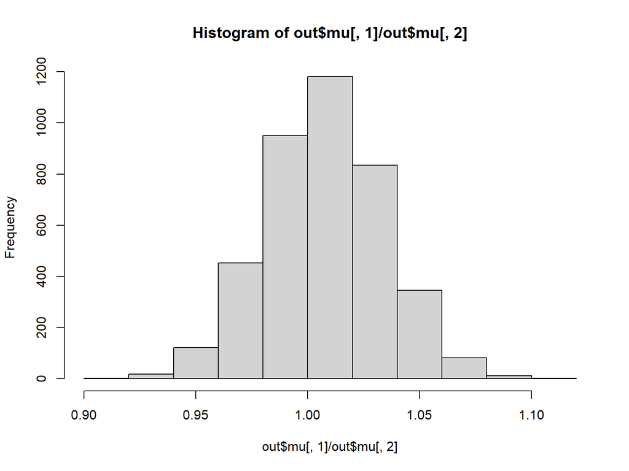

```r
hist(out$mu[,1]/out$mu[,2])
```

# Diagnostic and Summary plots

Many of the following plots can also be created using the `plot` method on a `stan` object with the `plotfun` argument set to the part of the plotting function name after `stan_`.

## Quick summary

```r
stan_plot(BvD.fit1)
```

```
## ci_level: 0.8 (80% intervals)
```

```
## outer_level: 0.95 (95% intervals)
```

## Quick summary

```
## ci_level: 0.8 (80% intervals)
```

```
## outer_level: 0.95 (95% intervals)
```

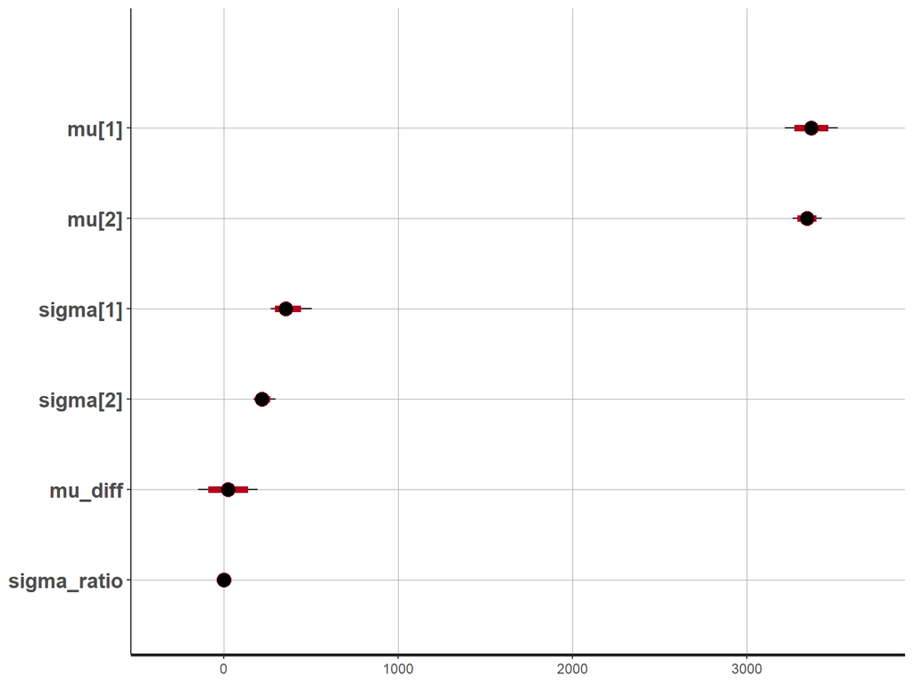

## Quick summary with options

```r
stan_plot(BvD.fit1, pars=c('mu','sigma'),
          point_est='mean',
          show_density=TRUE,
          ci_level=0.95,
          outer_level=0.99)
```

```
## ci_level: 0.95 (95% intervals)
```

```
## outer_level: 0.99 (99% intervals)
```

## Quick summary with options

```
## ci_level: 0.95 (95% intervals)
```

```
## outer_level: 0.99 (99% intervals)
```

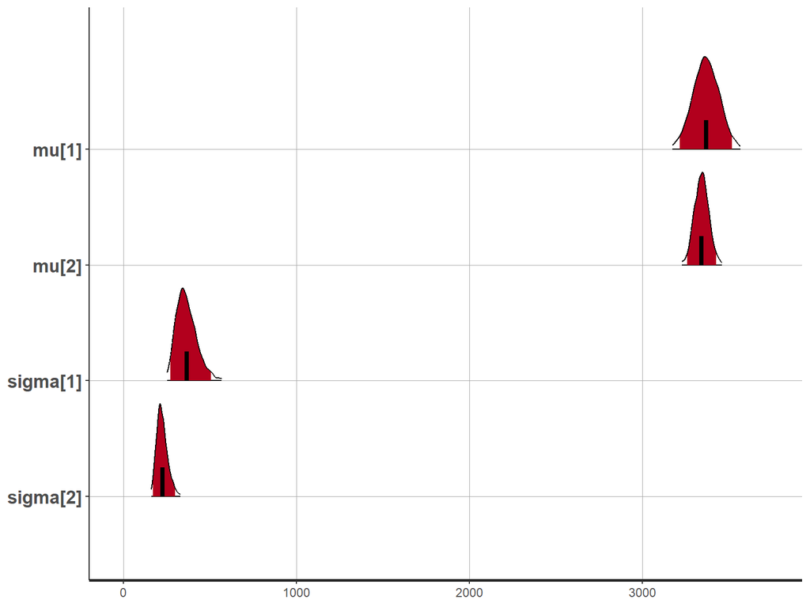

## Trace or catipillar plots

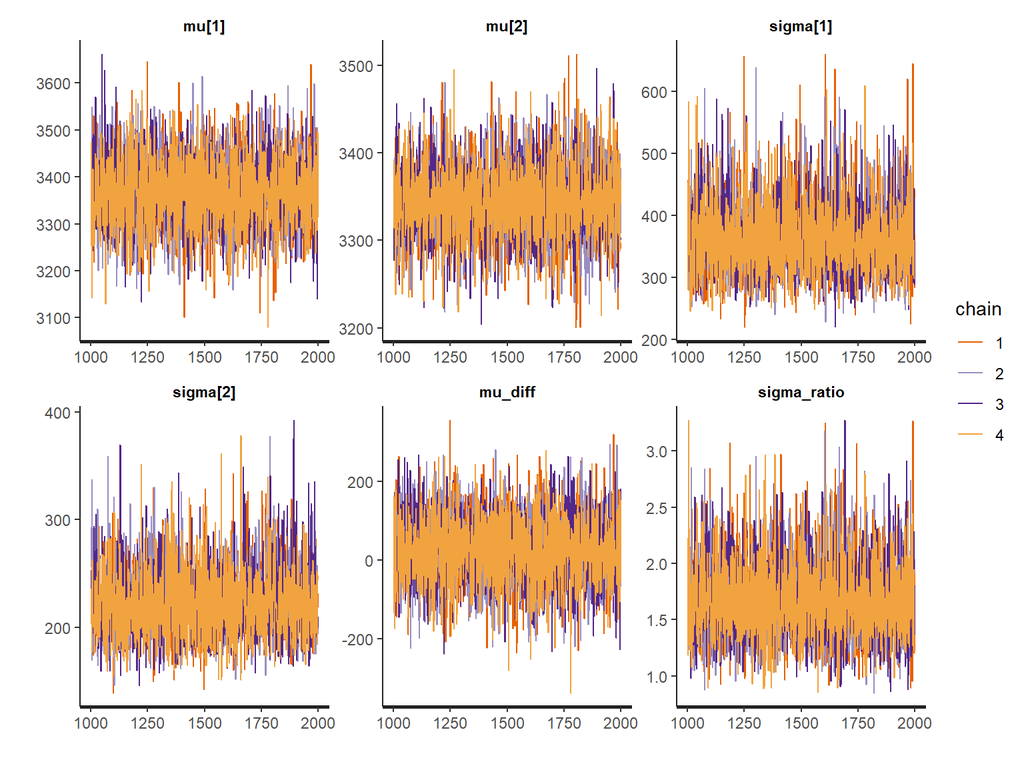

```r
stan_trace(BvD.fit1)
```

## Trace or catipillar plots

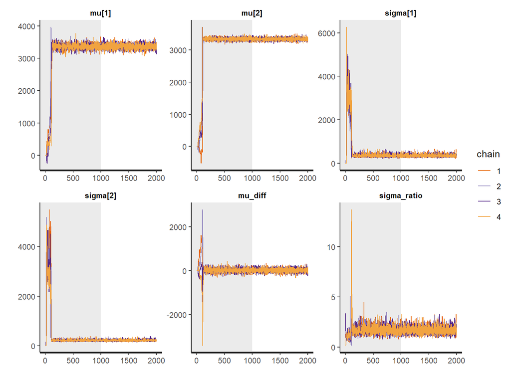

```r
stan_trace(BvD.fit1, inc_warmup=TRUE)
```

## Scatter plot

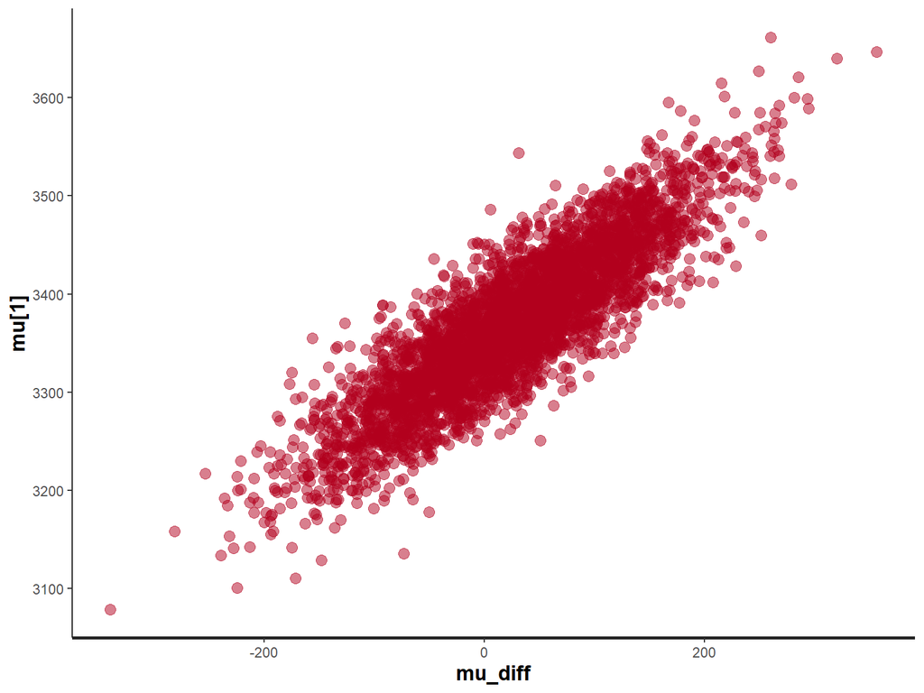

```r
stan_scat(BvD.fit1, pars=c('mu_diff', 'mu[1]'))
```

## Histogram

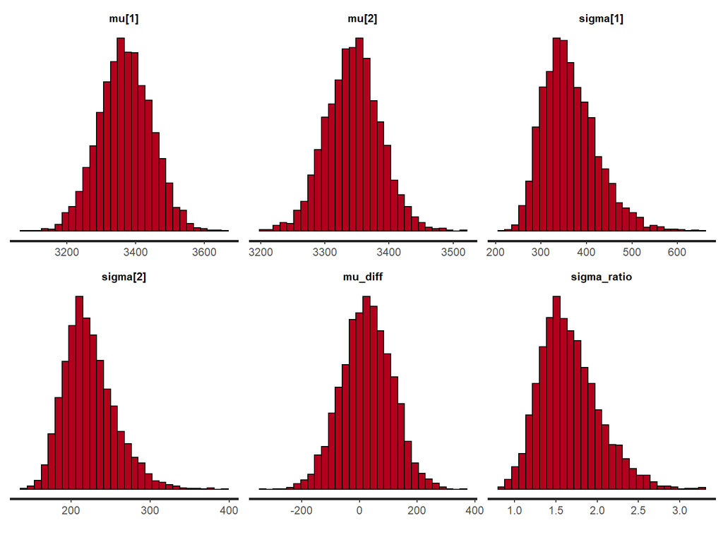

```r
stan_hist(BvD.fit1)
```

## Density plots

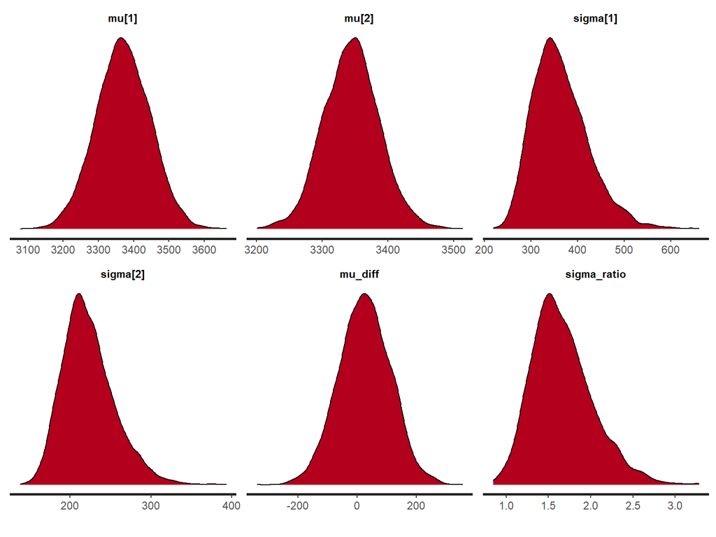

```r
stan_dens(BvD.fit1)
```

## Density plots

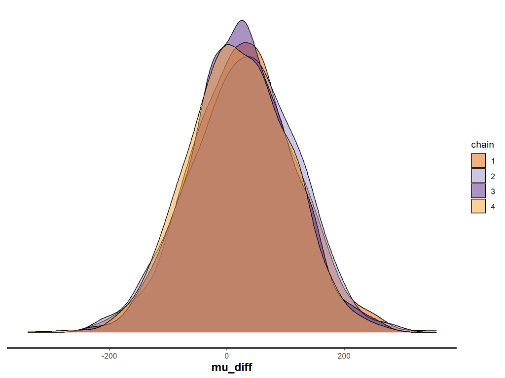

```r
stan_dens(BvD.fit1, pars='mu_diff', separate_chains=TRUE)
```

## Auto Correlation

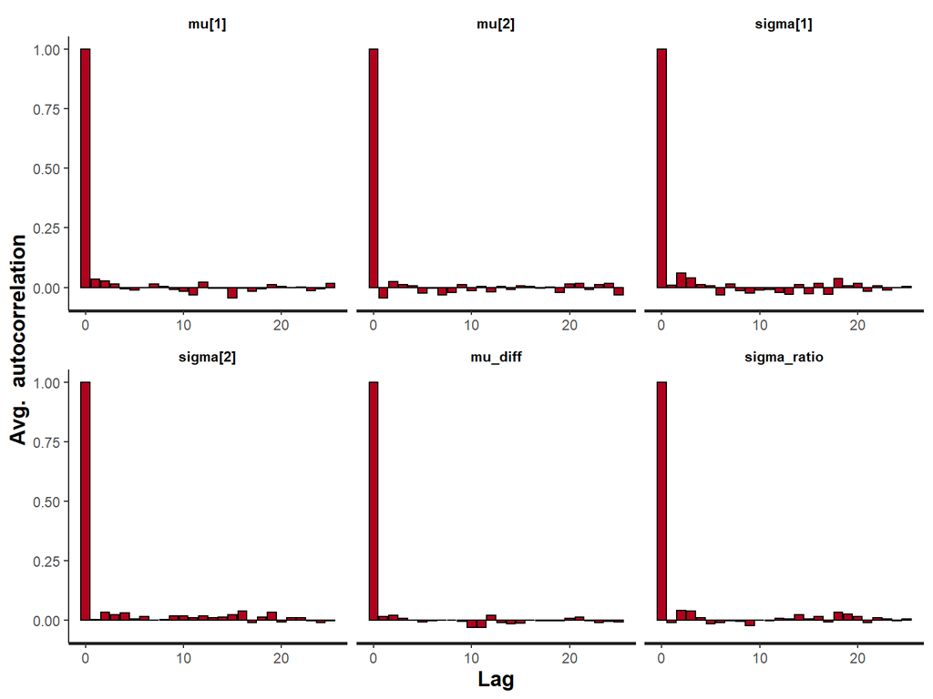

```r
stan_ac(BvD.fit1)
```

# Another Example

## Gentoo Penguins

Let’s repeat the example using Gentoo instead of Adelie penguins.

```r
w <- penguins$species=='Gentoo' &
      penguins$sex=='female' &
      penguins$island %in% c("Biscoe", "Dream") &
      !is.na(penguins$body_mass_g) &
      !is.na(penguins$sex)

BvD.standat2 <- list(
  N=sum(w),
  y=penguins$body_mass_g[w],
  g=as.integer(penguins$island[w])
)
```

## Gentoo Penguins

```r
BvD.fit2 <- sampling(twosamp.stan, BvD.standat2)
BvD.fit2
```

```
## Inference for Stan model: two_sample.
## 4 chains, each with iter=2000; warmup=1000; thin=1;
## post-warmup draws per chain=1000, total post-warmup draws=4000.
##
##                      mean se_mean       sd           2.5%            25%
## mu[1]        4.613590e+03   76.17   458.89   4.081840e+03   4.650640e+03
## mu[2]        1.102720e+03 5584.89 11296.16  -1.954210e+04  -6.584620e+03
## sigma[1]     3.549300e+02   75.08   438.86   2.404600e+02   2.695600e+02
## sigma[2]    8.961986e+307     NaN      Inf  3.977680e+306  4.410129e+307
## mu_diff      3.510870e+03 5583.46 11296.99  -1.735556e+04  -3.988860e+03
## sigma_ratio  0.000000e+00     NaN     0.00   0.000000e+00   0.000000e+00
## lp__         3.545300e+02    3.36    19.52   3.037400e+02   3.567900e+02
##                       50%           75%         97.5% n_eff Rhat
## mu[1]        4.677850e+03  4.705280e+03  4.754050e+03    36 1.08
## mu[2]        9.263200e+02  8.642510e+03  2.205661e+04     4 2.16
## sigma[1]     2.865800e+02  3.087500e+02  9.628300e+02    34 1.08
## sigma[2]    8.922395e+307 1.367191e+308 1.751298e+308   NaN  NaN
## mu_diff      3.573330e+03  1.129333e+04  2.422844e+04     4 2.15
## sigma_ratio  0.000000e+00  0.000000e+00  0.000000e+00   NaN  NaN
## lp__         3.579700e+02  3.587400e+02  3.595200e+02    34 1.09
##
## Samples were drawn using NUTS(diag_e) at Tue Sep 21 14:38:30 2021.
## For each parameter, n_eff is a crude measure of effective sample size,
## and Rhat is the potential scale reduction factor on split chains (at
## convergence, Rhat=1).
```

## Trace plot

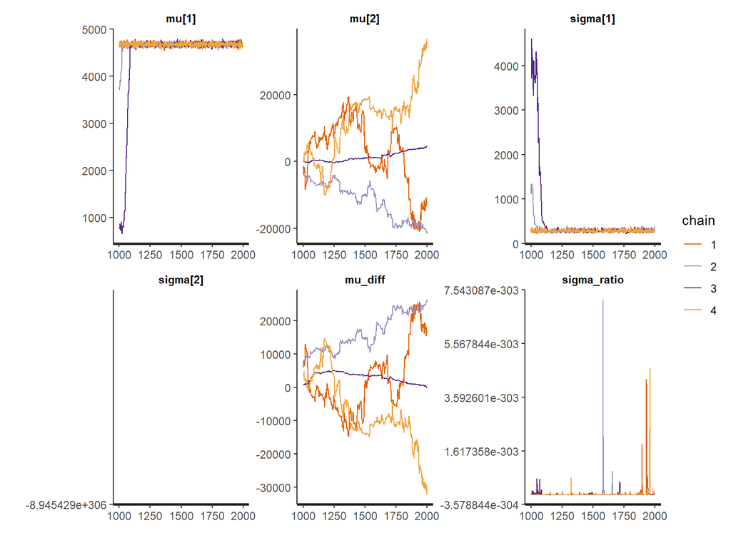

```r
stan_trace(BvD.fit2)
```

## Why

```r
with(penguins, table(island, species))
```

```
##            species
## island      Adelie Chinstrap Gentoo
##   Biscoe        44         0    124
##   Dream         56        68      0
##   Torgersen     52         0      0
```

## Reparameterization

From section 21.7 of the Stan Users Guide:

```stan
parameters {
  real y;
  vector[9] x;
}
model {
  y ~ normal(0, 3);
  x ~ normal(0, exp(y/2));
}
```

```r
rep.fit <- sampling(reparam)
rep.fit
```

```
## Inference for Stan model: 481cf10d138ca2a038059feaf162e7b6.
## 4 chains, each with iter=2000; warmup=1000; thin=1;
## post-warmup draws per chain=1000, total post-warmup draws=4000.
##
##        mean se_mean    sd   2.5%    25%   50%   75% 97.5% n_eff Rhat
## y      1.40    0.22  2.27  -2.43  -0.25  1.11  2.85  6.37   103 1.02
## x[1]  -0.08    0.10  8.35 -14.70  -1.09  0.01  1.06 13.85  6864 1.00
## x[2]   0.07    0.13  8.53 -13.41  -1.10  0.01  1.08 13.75  4034 1.00
## x[3]   0.06    0.09  7.23 -13.36  -1.13  0.00  1.05 13.77  5795 1.00
## x[4]   0.05    0.12  8.17 -13.90  -1.09 -0.05  1.12 12.35  4441 1.00
## x[5]   0.09    0.09  7.13 -13.08  -0.99  0.01  1.17 14.10  6199 1.00
## x[6]   0.09    0.10  7.82 -14.40  -1.08 -0.04  1.13 15.04  5546 1.00
## x[7]   0.03    0.13  8.29 -13.20  -1.01 -0.04  1.14 13.55  3913 1.00
## x[8]  -0.03    0.12  7.49 -13.88  -1.18  0.00  1.12 13.70  4091 1.00
## x[9]   0.12    0.12  7.72 -13.61  -1.04  0.02  1.17 13.03  4150 1.00
## lp__ -11.22    1.09 10.91 -35.96 -17.81 -9.86 -3.26  6.25   101 1.02
##
## Samples were drawn using NUTS(diag_e) at Tue Sep 21 14:40:05 2021.
## For each parameter, n_eff is a crude measure of effective sample size,
## and Rhat is the potential scale reduction factor on split chains (at
## convergence, Rhat=1).
```

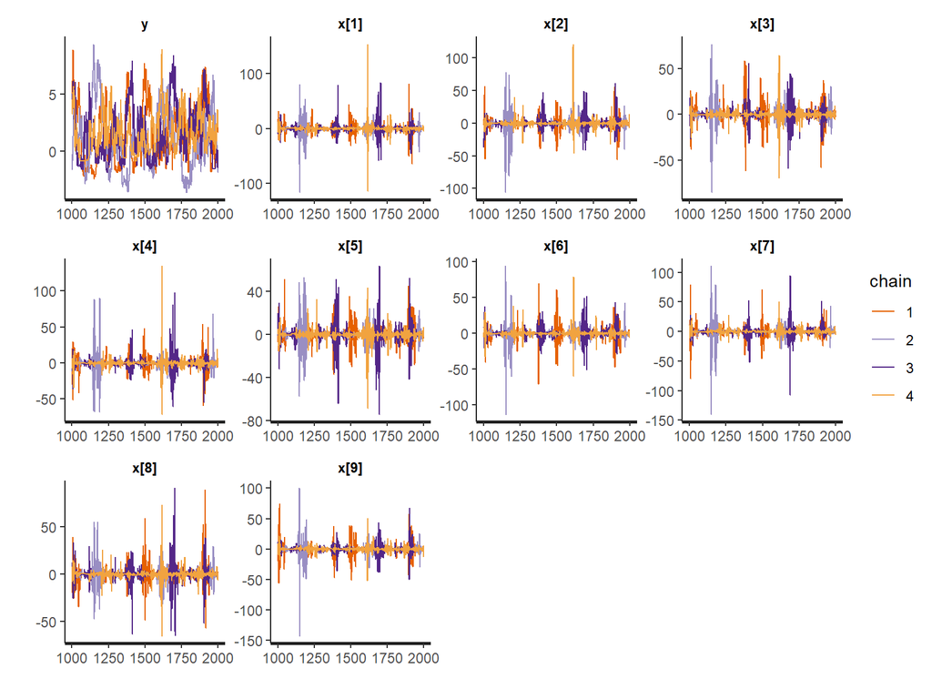

```r
stan_trace(rep.fit)
```

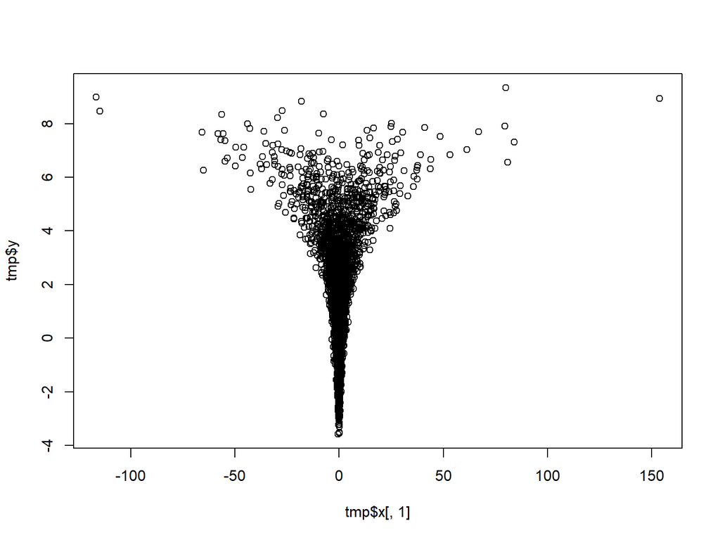

```r
tmp <- extract(rep.fit)
plot(tmp$x[,1], tmp$y)
```

## Reparameterized

```stan
parameters {
  real y_raw;
  vector[9] x_raw;
}
transformed parameters {
  real y;
  vector[9] x;

  y = 3.0 * y_raw;
  x = exp(y/2) * x_raw;
}
model {
  y_raw ~ std_normal(); // implies y ~ normal(0, 3)
  x_raw ~ std_normal(); // implies x ~ normal(0, exp(y/2))
}
```

```r
rep.fit2 <- sampling(reparam2)
```

```r
rep.fit2
```

```
## Inference for Stan model: d70a77024adf419ffc8a741863e1f803.
## 4 chains, each with iter=2000; warmup=1000; thin=1;
## post-warmup draws per chain=1000, total post-warmup draws=4000.
##
##           mean se_mean   sd   2.5%   25%   50%   75% 97.5% n_eff Rhat
## y_raw     0.00    0.01 0.99  -1.93 -0.69  0.00  0.69  1.92  8639    1
## x_raw[1] -0.01    0.01 0.99  -1.92 -0.65 -0.01  0.67  1.91  7618    1
## x_raw[2]  0.01    0.01 0.97  -1.89 -0.65  0.00  0.66  1.93  8185    1
## x_raw[3]  0.02    0.01 1.02  -2.00 -0.68  0.04  0.69  2.03  7676    1
## x_raw[4]  0.01    0.01 0.98  -1.95 -0.66  0.00  0.67  1.96  7635    1
## x_raw[5]  0.01    0.01 0.97  -1.89 -0.64 -0.01  0.65  2.01  6695    1
## x_raw[6] -0.01    0.01 0.99  -1.93 -0.69 -0.03  0.66  1.98  8977    1
## x_raw[7]  0.02    0.01 1.00  -1.96 -0.66  0.03  0.70  1.97  7496    1
## x_raw[8] -0.01    0.01 0.99  -1.98 -0.67 -0.01  0.66  1.90  8632    1
## x_raw[9]  0.00    0.01 0.97  -1.93 -0.64  0.01  0.64  1.88  8806    1
## y         0.00    0.03 2.98  -5.80 -2.07 -0.01  2.07  5.75  8639    1
## x[1]     -0.08    0.11 6.85  -9.27 -0.58  0.00  0.56  9.42  4236    1
## x[2]      0.21    0.11 6.20  -8.15 -0.53  0.00  0.56  9.43  3221    1
## x[3]      0.23    0.13 7.08  -8.22 -0.54  0.01  0.64  9.63  2916    1
## x[4]     -0.12    0.13 7.40  -9.54 -0.54  0.00  0.58  8.11  3223    1
## x[5]      0.11    0.14 8.08  -8.49 -0.56 -0.01  0.55  9.85  3581    1
## x[6]     -0.06    0.11 6.48 -10.41 -0.60 -0.01  0.52  9.00  3394    1
## x[7]     -0.07    0.13 7.12  -9.45 -0.55  0.01  0.58  9.76  3218    1
## x[8]     -0.08    0.13 7.36  -9.20 -0.58  0.00  0.57  9.63  3193    1
## x[9]     -0.01    0.10 6.35  -8.68 -0.58  0.00  0.52  8.57  3734    1
## lp__     -4.89    0.05 2.19  -9.88 -6.15 -4.55 -3.29 -1.64  1858    1
##
## Samples were drawn using NUTS(diag_e) at Tue Sep 21 14:41:46 2021.
## For each parameter, n_eff is a crude measure of effective sample size,
## and Rhat is the potential scale reduction factor on split chains (at
## convergence, Rhat=1).
```

```r
stan_trace(rep.fit2)
```

```
## 'pars' not specified. Showing first 10 parameters by default.
```

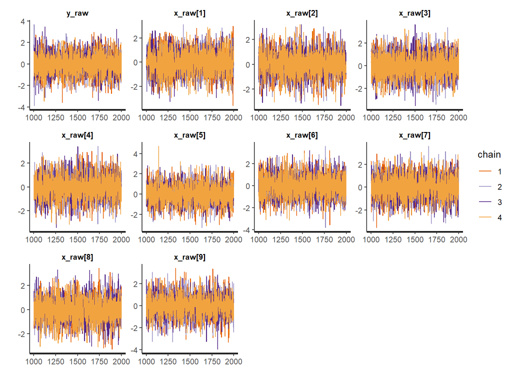

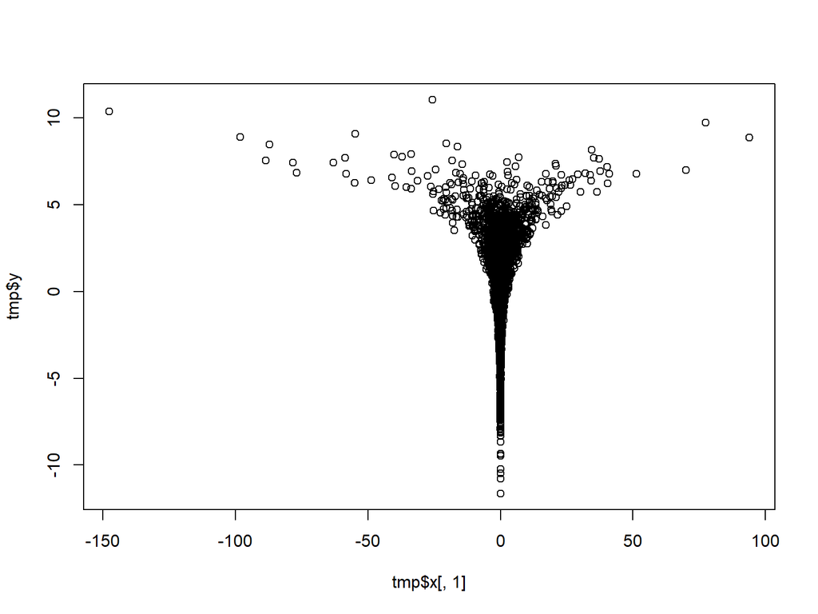

```r
tmp <- extract(rep.fit2)
plot(tmp$x[,1], tmp$y)
```

# shinystan

What if …

- I have trouble remembering all those plot commands?
- I like clicking with the mouse more than typing at the keyboard?
- I just want to do some quick exploration of the fitted model?

## The shinystan package

```r
library(shinystan)
launch_shinystan(BvD.fit1)
```

## shinystan

[figure not shown]

## shinystan

[figure not shown]

## shinystan

[figure not shown]

## shinystan

[figure not shown]

# rstanarm

I just want to fit a standard regression model, do I really need to write my own Stan code and Compile it?

## rstanarm

The `rstanarm` package has pre-compiled Stan code for several common models. It also has R functions that are similar to the regular R functions for the models that will call the Stan models for you.

## rstanarm

```r
library(rstanarm)
fit1 <- stan_aov(body_mass_g ~ island, data=penguins,
                 prior=R2(0.7, what='mean'))
summary(fit1, probs=c(0.025, 0.5, 0.975))
```

```
##
## Model Info:
##  function:     stan_aov
##  family:       gaussian [identity]
##  formula:      body_mass_g ~ island
##  algorithm:    sampling
##  sample:       4000 (posterior sample size)
##  priors:       see help('prior_summary')
##  observations: 342
##
## Estimates:
##                   mean    sd      2.5%    50%     97.5%
## (Intercept)      4714.2    48.0  4618.9  4714.3  4811.1
## islandDream      -999.7    73.7 -1148.5  -998.6  -857.8
## islandTorgersen -1004.9   100.0 -1198.6 -1005.3  -804.8
## sigma             626.9    24.4   581.1   625.7   675.2
## log-fit_ratio       0.0     0.0    -0.1     0.0     0.1
## R2                  0.4     0.0     0.3     0.4     0.5
##
## Fit Diagnostics:
##            mean   sd     2.5%   50%    97.5%
## mean_PPD 4201.7   48.0 4108.3 4201.7 4296.4
##
## The mean_ppd is the sample average posterior predictive distribution of the outcome variable (for details see help('summary.stanreg')).
##
## MCMC diagnostics
##                 mcse Rhat n_eff
## (Intercept)     1.2  1.0  1542
## islandDream     1.8  1.0  1626
## islandTorgersen 2.1  1.0  2218
## sigma           0.5  1.0  2261
## log-fit_ratio   0.0  1.0  1652
## R2              0.0  1.0  1600
## mean_PPD        0.8  1.0  3688
## log-posterior   0.1  1.0  1070
##
## For each parameter, mcse is Monte Carlo standard error, n_eff is a crude measure of effective sample size, and Rhat is the potential scale reduction factor on split chains (at convergence Rhat=1).
```

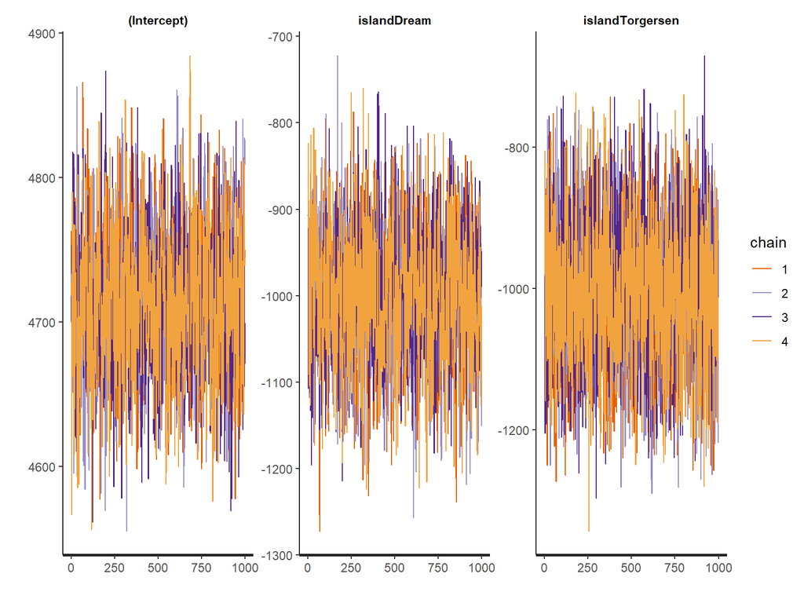

```r
stan_trace(fit1)
```

```
## ci_level: 0.95 (95% intervals)
```

```
## outer_level: 0.99 (99% intervals)
```

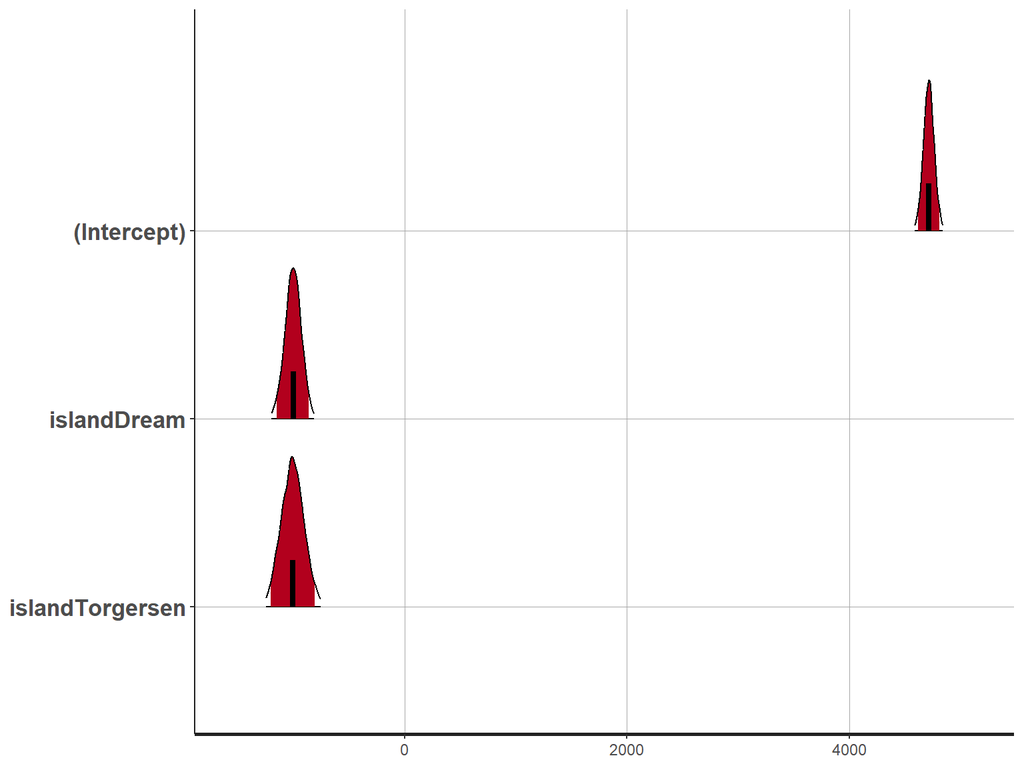

```r
stan_plot(fit1, show_density=TRUE,
          ci_level=0.95, outer_level=0.99)
```

## rstanarm

Note that `stan_aov` and `stan_lm` only allow a general prior on $R^2$.

Use `stan_glm` to set priors on individual coefficients.

## stan_glm

```r
penguins$island <- factor(penguins$island,
                          levels=c("Dream", "Torgersen", "Biscoe"))
fit2 <- stan_glm(body_mass_g ~ island,
                 data=penguins,
                 prior=hs())
```

```
## ci_level: 0.95 (95% intervals)
```

```
## outer_level: 0.99 (99% intervals)
```

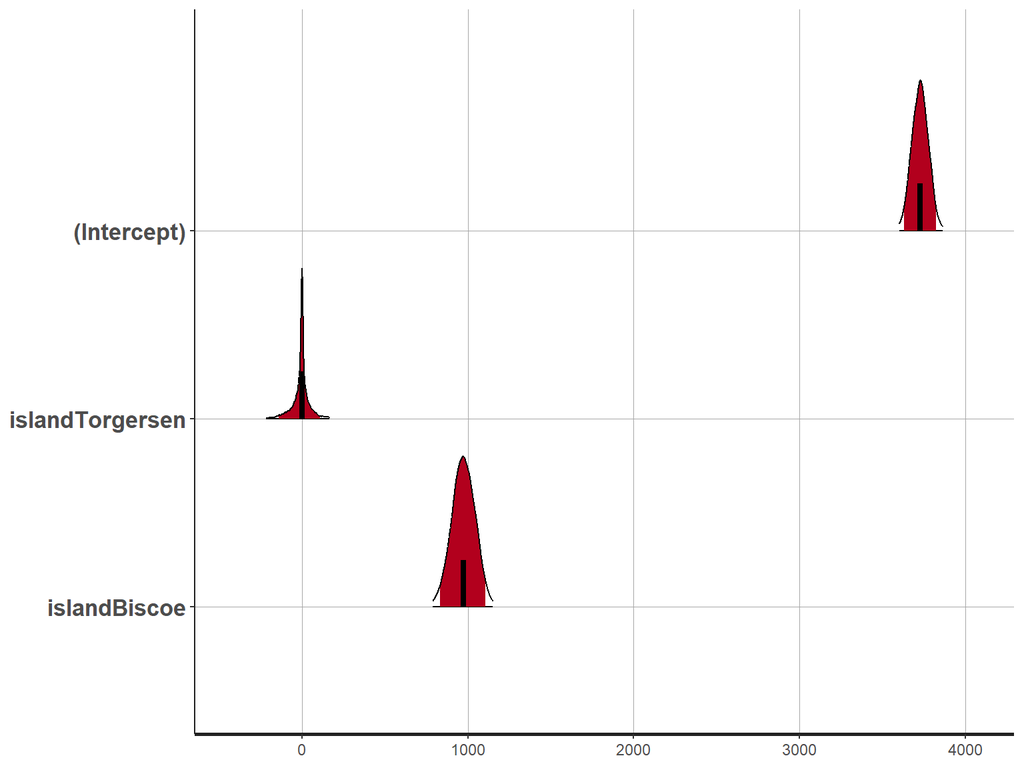

```r
stan_plot(fit2, show_density=TRUE,
          ci_level=0.95, outer_level=0.99)
```

## rstanarm

Some of the other models in `rstanarm`

- stan_betareg
- stan_clogit
- stan_glmer
- stan_jm
- stan_polr

## Greg’s opinion

If you fit a pre-compiled model, use the default priors, and only look at the Intervals in the output; then you are not really doing Bayesian statistics.

# brms

The `brms` package focuses more on hierarchical models.

Like `rstanarm` the interface is like regular R functions.

## brms example

```r
library(brms)

fit3 <- brm(formula = time | cens(censored) ~ age * sex +
              disease + (1 + age|patient),
  data = kidney, family = lognormal(),
  prior = c(set_prior("normal(0,5)", class = "b"),
    set_prior("cauchy(0,2)", class = "sd"),
    set_prior("lkj(2)", class = "cor")),
  warmup = 1000, iter = 2000, chains = 4,
  control = list(adapt_delta = 0.95))
fit3
```

```
##  Family: lognormal
##   Links: mu = identity; sigma = identity
## Formula: time | cens(censored) ~ age * sex + disease + (1 + age | patient)
##    Data: kidney (Number of observations: 76)
## Samples: 4 chains, each with iter = 2000; warmup = 1000; thin = 1;
##          total post-warmup samples = 4000
##
## Group-Level Effects:
## ~patient (Number of levels: 38)
##                    Estimate Est.Error l-95% CI u-95% CI Rhat Bulk_ESS Tail_ESS
## sd(Intercept)          0.42      0.29     0.02     1.06 1.00     1137     1883
## sd(age)                0.01      0.01     0.00     0.02 1.01      849     1631
## cor(Intercept,age)    -0.14      0.45    -0.87     0.74 1.00     2625     2962
##
## Population-Level Effects:
##               Estimate Est.Error l-95% CI u-95% CI Rhat Bulk_ESS Tail_ESS
## Intercept         2.74      0.95     0.80     4.56 1.00     2078     2244
## age               0.01      0.02    -0.03     0.06 1.00     1817     1892
## sexfemale         2.42      1.13     0.25     4.72 1.00     1954     2196
## diseaseGN        -0.39      0.53    -1.44     0.65 1.00     2446     2653
## diseaseAN        -0.51      0.53    -1.55     0.55 1.00     2600     2802
## diseasePKD        0.61      0.74    -0.87     2.12 1.00     2789     2370
## age:sexfemale    -0.02      0.03    -0.07     0.03 1.00     1998     2219
##
## Family Specific Parameters:
##       Estimate Est.Error l-95% CI u-95% CI Rhat Bulk_ESS Tail_ESS
## sigma     1.14      0.13     0.91     1.43 1.00     2251     2854
##
## Samples were drawn using sampling(NUTS). For each parameter, Bulk_ESS
## and Tail_ESS are effective sample size measures, and Rhat is the potential
## scale reduction factor on split chains (at convergence, Rhat = 1).
```

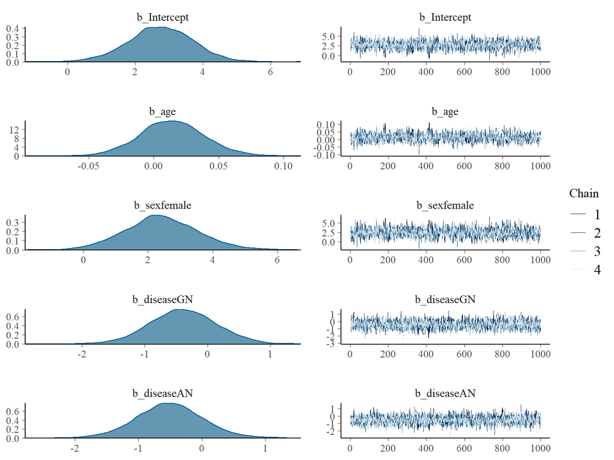

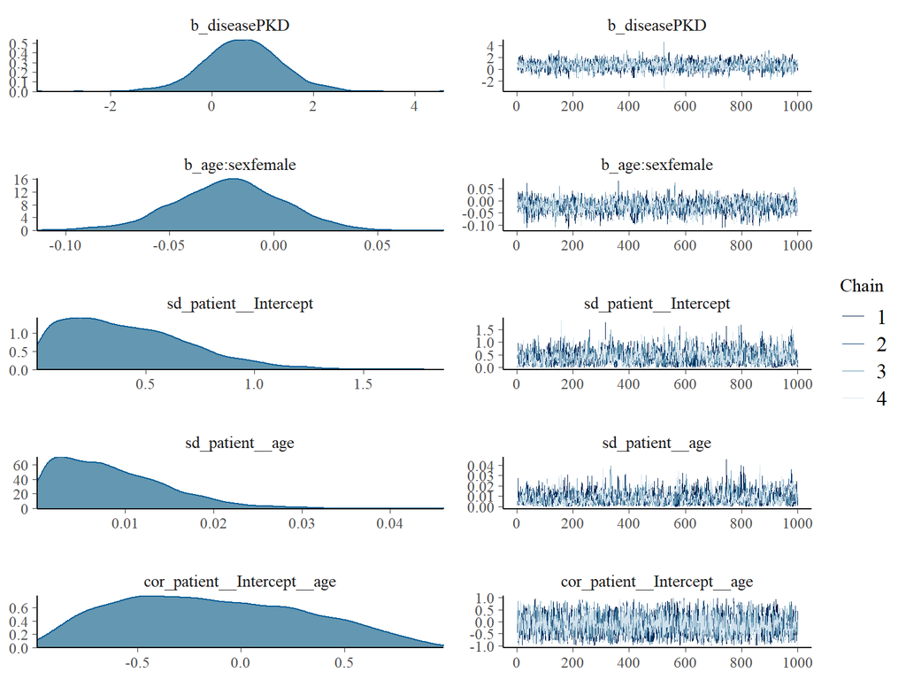

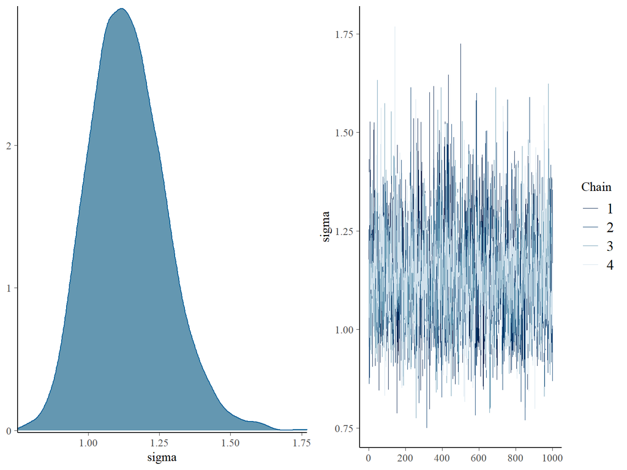

```r
plot(fit3)
```

# Leave One Out cross-validation

The `loo` package does Leave One Out cross-validation as a method of identifying influential points and getting an overall measure of the fit of a model (which can then be used to compare models).

The `rstanarm` and `brms` packages have built-in connections to the `loo` package.

## Comparing models

```r
penguins <- penguins[!is.na(penguins$sex),]
fit1 <- stan_glm(body_mass_g ~ species,
                 data = penguins)
fit2 <- stan_glm(body_mass_g ~ species + sex,
                 data = penguins)
fit3 <- stan_glm(body_mass_g ~ species*sex,
                 data=penguins)
# (for bigger models use as many cores as possible)
loo1 <- loo(fit1, cores = 4)
loo2 <- loo(fit2, cores = 4)
loo3 <- loo(fit3, cores = 4)
```

```r
loo1
```

[output not shown]

```r
loo2
```

```
##
## Computed from 4000 by 333 log-likelihood matrix
##
##          Estimate   SE
## elpd_loo  -2392.9 12.0
## p_loo         5.0  0.4
## looic      4785.8 24.1
## ------
## Monte Carlo SE of elpd_loo is 0.0.
##
## All Pareto k estimates are good (k < 0.5).
## See help('pareto-k-diagnostic') for details.
```

```r
loo3
```

```
##
## Computed from 4000 by 333 log-likelihood matrix
##
##          Estimate   SE
## elpd_loo  -2386.2 12.2
## p_loo         6.9  0.6
## looic      4772.3 24.4
## ------
## Monte Carlo SE of elpd_loo is 0.0.
##
## All Pareto k estimates are good (k < 0.5).
## See help('pareto-k-diagnostic') for details.
```

```r
loo_compare(loo1, loo2, loo3)
```

[output not shown]

# Others

There ar a bunch of other packages that depend, import, or link to `rstan` fitting specific models. See: https://cran.r-project.org/web/packages/rstan/index.html